**Machine Learning for Mechanical Engineering**  
**Homework 03 - Solution**

Prof. Seungchul Lee  
http://iai.postech.ac.kr/  
Industrial AI Lab at POSTECH

# Problem 2

The regularized least-squares problem has the form

$$ \min_{\theta} \;\lVert A\theta -y\rVert_2^2 + \lambda \lVert \theta \rVert_2^2$$

(a) Show that the solution is given by
$$ \hat{\theta} = \left( A^T A + \lambda I_n \right)^{-1} A^T y $$

- Do not use the method of Lagrangian multipliers

(b) Write down a gradient descent algorithm for the given optimization problem.

- Hint: Note that $$ \;\lVert A\theta -y\rVert_2^2 = (A\theta - y)^T(A\theta - y)$$
  Then, you can differentiate the above equation to compute the gradient. Likewise, you can compute the gradient of the regularizer.

(c) Based on the result of (b), describe the role of regularizer term.

- Hint: Gradient $g$ is computed by $ g = g_{\text{projection}} + g_{\text{regularizer}} $.

(d) Describe results of (a) and (b) have the same meaning.

(e) Find and draw an approximated curve of the given data points below in Python using your gradient descent algorithm.

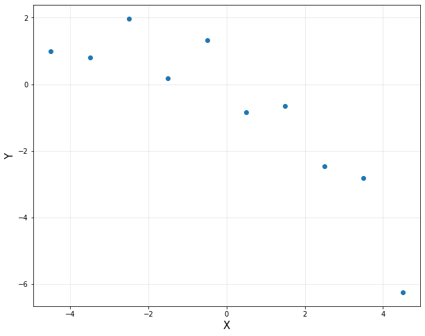

```python
import numpy as np
import matplotlib.pyplot as plt
%matplotlib inline

# 10 data points
n = 10
x = np.linspace(-4.5, 4.5, 10).reshape(-1, 1)
y = np.array([0.9819, 0.7973, 1.9737, 0.1838, 1.3180, -0.8361, -0.6591, -2.4701, -2.8122, -6.2512]).reshape(-1, 1)

plt.figure(figsize = (10, 8))
plt.plot(x, y, 'o', label = 'Data')
plt.xlabel('X', fontsize = 15)
plt.ylabel('Y', fontsize = 15)
plt.grid(alpha = 0.3)
plt.show()
```

```python
# your code here
```

# Solution 2

(a) Sum of 2-norms of multiple vectors can be expressed as a 2-norm of a single vector.

$$ \begin{align*} \left\Vert A\theta - y\big\Vert^2_{2} + \big\Vert \sqrt{\lambda}I\theta-0\right\Vert^2_{2} & = \Bigg\Vert \begin{bmatrix} A\\ \sqrt{\lambda}I \end{bmatrix} \theta- \begin{bmatrix} y\\ 0 \end{bmatrix} \Bigg\Vert^2_{2} \end{align*}$$

$$ \hat{\theta} = \left( \begin{bmatrix} A\\ \sqrt{\lambda}I \end{bmatrix}^T \begin{bmatrix} A\\ \sqrt{\lambda}I \end{bmatrix}\right)^{-1}\begin{bmatrix} A\\ \sqrt{\lambda}I \end{bmatrix}^T \begin{bmatrix} y\\ 0 \end{bmatrix} = \left( A^T A + \lambda I_n \right)^{-1} A^T y $$

(b) Let $J(\theta) = \Vert A\theta - y \Vert_2^2 + \lambda \Vert \theta \Vert_2^2$. A gradient descent algorithm is formulated as the following,

$$ \theta \leftarrow \theta - \eta \frac{\partial{J}}{\partial{\theta}}. $$

Need to compute $\frac{\partial{J}}{\partial{\theta}}$.

$$ \begin{align*} g_{\text{projection}} &= \frac{\partial}{\partial{\theta}} \Vert A\theta - y \Vert_2^2 \\ &= \frac{\partial}{\partial{\theta}} (A\theta - y)^T(A\theta - y) \\ &= \frac{\partial}{\partial{\theta}} (\theta^T A^T A \theta - 2\theta^T A^T y - y^Ty) \\ &= 2A^TA \theta - 2A^Ty \\ \\ g_{\text{regularizer}} &= \frac{\partial}{\partial{\theta}} \Vert \theta \Vert_2^2 \\ &= \frac{\partial}{\partial{\theta}} \theta^T \theta \\ &= 2 \theta. \end{align*} $$

Therefore,

$$ \begin{align*} \frac{\partial{J}}{\partial{\theta}} &= g_{\text{projection}} + \lambda g_{\text{regularizer}} \\ &= 2A^TA \theta - 2A^Ty + \lambda 2 \theta. \end{align*} $$

Then, the gradient descent algorithm is formulated as the following

$$ \theta \leftarrow \theta - \eta(2A^TA \theta - 2A^Ty + \lambda 2 \theta). $$

(c)

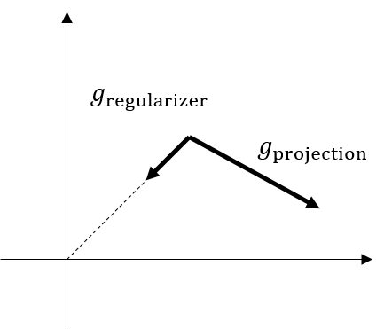

$g_{\text{regularizer}}$ tends to make $\theta$ converge to zero. Since $g = g_{\text{projection}} + \lambda g_{\text{regularizer}}$, we can see that the regularizer $g_{\text{regularizer}}$ tries to keep the value of $\theta$ small.

(d)

Likewise, (a) shows that

$$ (A^T A)^{-1} A^Ty \quad \rightarrow \quad (A^T A + \lambda I_n)^{-1} A^Ty. $$

From the solution of (a),

$$ \nabla_\theta^2 f(\theta) = 2\left(A^TA + \lambda I_n \right)^T \geq 0 \quad \left(\because A^TA = \lVert A \rVert^2,\quad \lambda \geq 0 \right)$$

so, this problem is a convex problem

From solution of (b), if the number of iteration become enough, $\theta_{i+1} \approx \theta_i = \hat{\theta} $ in equation $\theta_{i+1} \leftarrow \theta_i - \alpha g\left(\theta_i \right) $, so

$$ \begin{align*} g\left(\hat{\theta} \right) = 2A^TA \theta - 2A^Ty + \lambda 2 \theta = 0\\ \end{align*} $$

$$ \begin{align*} \left( A^T A + \lambda I_n \right)\hat{\theta} = A^T y \end{align*} $$$$ \begin{align*} \therefore \hat{\theta} = \left( A^T A + \lambda I_n \right)^{-1} A^T y \end{align*} $$

Therefore (a) and (b) are same meaning

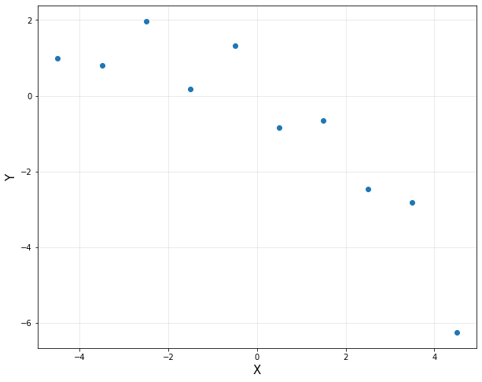

```python
import numpy as np
import matplotlib.pyplot as plt

x = np.linspace(-4.5, 4.5, 10)
y = np.array([0.9819, 0.7973, 1.9737, 0.1838, 1.3180, -0.8361, -0.6591, -2.4701, -2.8122, -6.2512])

plt.figure(figsize = (10, 8))
plt.plot(x, y, 'o', label = 'Data')
plt.xlabel('X', fontsize = 15)
plt.ylabel('Y', fontsize = 15)
plt.grid(alpha = 0.3)
plt.show()
```

```python
m = np.shape(x)[0]
x = np.reshape(x,(-1,1))
y = np.reshape(y,(-1,1))

X = np.hstack([np.ones([m,1]), x, x**2, x**3, x**4, x**5])
X = np.asmatrix(X)
y = np.asmatrix(y)

theta = np.ones([6,1])
lamda = 1
alpha = 1e-7
n_iter = 100000

for i in range(n_iter):
    g = 2*X.T*X*theta - 2*X.T*y + 2*lamda*theta
    theta = theta - alpha*g

print(theta)
```

```
[[ 0.75330967]
 [ 0.6793209 ]
 [ 0.02933984]
 [-0.20172918]
 [-0.0104212 ]
 [ 0.00646841]]
```

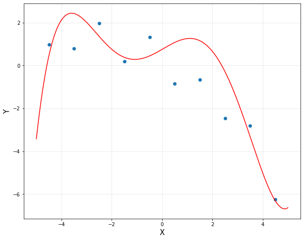

```python
xp = np.linspace(-5,5,1000)
yp = theta[0,0] + theta[1,0]*xp + theta[2,0]*xp**2 + theta[3,0]*xp**3 + \
     theta[4,0]*xp**4 + theta[5,0]*xp**5

plt.figure(figsize = (10, 8))
plt.plot(x, y, 'o', label = 'Data')
plt.plot(xp,yp, 'r')
plt.xlabel('X', fontsize = 15)
plt.ylabel('Y', fontsize = 15)
plt.grid(alpha = 0.3)
plt.show()
```

# Problem 3: Image Panorama with Regression

We want to demonstrate an image panorama as an example of linear regression. A panorama is any wide-angle view or representation of a physical space.

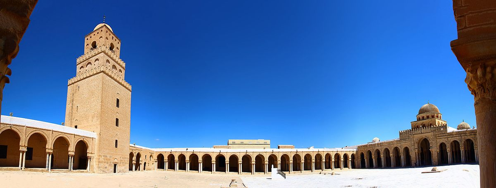

- You need to install the opencv module and download the images.
- opencv install
  - https://pypi.python.org/pypi/opencv-python
- Image download
  - https://www.dropbox.com/s/vlmp67zlq4mo0um/HW1.zip?dl=1

```python
# import library
import numpy as np
import matplotlib.pyplot as plt
import cv2
# load images
imag1 = cv2.imread('./data_files/1.jpg')
imag1 = cv2.cvtColor(imag1, cv2.COLOR_BGR2RGB)
imag2 = cv2.imread('./data_files/2.jpg')
imag2 = cv2.cvtColor(imag2, cv2.COLOR_BGR2RGB)
imag3 = cv2.imread('./data_files/3.jpg')
imag3 = cv2.cvtColor(imag3, cv2.COLOR_BGR2RGB)
```

```python
## your code here
#
```

```python
## your code here
#
```

```python
## your code here
#
```

**Panorama**

Here, we are explaining the basic concept of homography (i.e., perspective transformation).

- Any wide-angle view or representation of a physical space
- images with horizontally elongated fields of view
- idea: projecting images onto a common plane

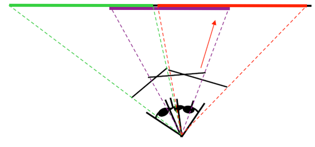

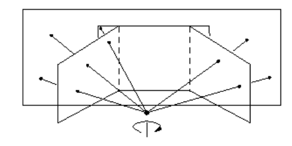

- Camera rotating about its center

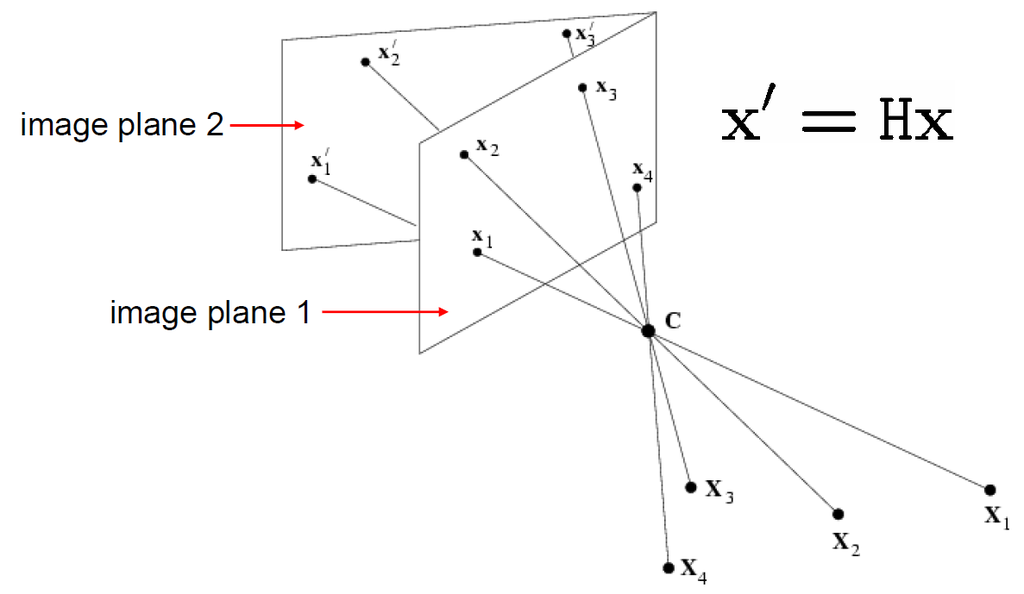

- Two image planes are related by a homography $H$

  Do not worry about a homography transformation. (out of this course's scope)

$$ \begin{bmatrix} x'\\y'\\1 \end{bmatrix} \sim \begin{bmatrix} \omega x'\\\omega y'\\\omega \end{bmatrix} = \begin{bmatrix} a & b & c \\ d & e & f \\ g & h & 1 \end{bmatrix} \begin{bmatrix} x\\y\\1 \end{bmatrix} $$

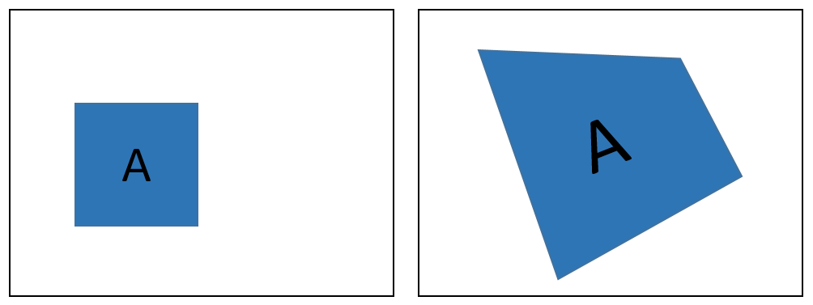

## Find key points between two images

- Suppose these matching points are given.
  - We have manually found the matching points for you, although there is a technique to do this automatically.
- pos1 and pos2 are matching points between img01 and img02
- pos3 and pos4 are matching points between img02 and img03

```python
pos1 = np.array([[2121, 2117, 2749, 3095, 3032, 3375, 3677, 3876],
                 [1431, 2034, 2033, 1885, 2017, 2037, 1885, 2279]], dtype=np.int64)
pos2 = np.array([[188, 58, 828, 1203, 1121, 1437, 1717, 1817],
                 [1217, 1909, 1952, 1827, 1952, 1991, 1870, 2226]], dtype=np.int64)
pos3 = np.array([[2338, 2379, 2658, 2899, 2977, 3272, 2716, 2786],
                 [1948, 1874, 2000, 1837, 1964, 1966, 2143, 2317]], dtype=np.int64)
pos4 = np.array([[109, 178, 497, 795, 851, 1144, 534, 580],
                 [1907, 1828, 1988, 1834, 1971, 1993, 2145, 2333]], dtype=np.int64)
```

(a) Visualization of key points

```python
## your code here
## Write down your own code to mark the key points (red dots) on the locations of the given images
#
```

**Estimation of homography H**

$$ X' = HX $$

where $ X $ and $X'$ are position vectors of key points, and $ H $ is a Perspective Transformation

**Goal: we need to estimate homography $H$ via matching points between two images**

$$\begin{bmatrix} x' \\ y' \\ 1 \end{bmatrix} \sim \begin{bmatrix} \omega x' \\ \omega y' \\ \omega \end{bmatrix} = \begin{bmatrix} \theta_{1} & \theta_{2} & \theta_{3} \\ \theta_{4} & \theta_{5} & \theta_{6} \\ \theta_{7} & \theta_{8} & 1 \end{bmatrix} \begin{bmatrix} x\\ y\\ 1 \end{bmatrix}$$

(b) Show the following equations from the above homography $H$

$$ \begin{align*} x' &= \frac{\theta_1 x+\theta_2 y+\theta_3}{\theta_7 x+\theta_8 y+1} \\ y' &= \frac{\theta_4 x+\theta_5 y+\theta_6}{\theta_7 x+\theta_8 y+1} \end{align*} $$
$$ \begin{align*} \theta_1 x+\theta_2 y+\theta_3 -\theta_7 x'x-\theta_8 x'y-x' &= 0 \\ \theta_4 x+\theta_5 y+\theta_6 -\theta_7 y'x-\theta_8 y'y-y' &= 0 \end{align*} $$

(c) For $m$ pairs of matching potins, show that a feature matrix $\Phi$ can be expressed as follows:

- $ \Phi $ is a feature matrix

$$ \Phi = \begin{bmatrix} x_{1} & y_{1} & 1 & 0 & 0 & 0 & -x'_{1}x_{1} & -x'_{1}y_{1}\\ 0 & 0 & 0 & x_{1} & y_{1} & 1 & -y'_{1}x_{1} & -y'_{1}y_{1}\\ \vdots &\vdots &\vdots &\vdots &\vdots &\vdots &\vdots &\vdots\\ x_{m} & y_{m} & 1 & 0 & 0 & 0 & -x'_{m}x_{m} & -x'_{m}y_{m}\\ 0 & 0 & 0 & x_{m} & y_{m} & 1 & -y'_{m}x_{m} & -y'_{m}y_{m}\end{bmatrix} $$

- $ \theta $ is a column vector for unknown parameters in a perspective transformation $H$

$$ \theta = \begin{bmatrix} \theta_{1} \\ \theta_{2} \\ \theta_{3} \\ \theta_{4} \\ \theta_{5} \\ \theta_{6} \\ \theta_{7} \\ \theta_{8} \end{bmatrix} $$

- $b$ is a column vector for corresponding positions in the base image

$$ b = \begin{bmatrix} x'_{1} \\ y'_{1} \\ x'_{2} \\ y'_{2} \\ \vdots \\ x'_{m} \\ y'_{m} \end{bmatrix} $$

- It ends up becoming a linear regression problem

$$ \min\limits_{\theta} \lVert \Phi\theta - b \rVert _2^2 $$$$ \theta^* = (\Phi^T\Phi)^{-1}\Phi^T b $$

(d) Perspective homography for image 1 and image 2

```python
## your code here
## Construct feature matrix using homography H, and a vector having entries of matching points in image 2




## your code here
## Define perspective_theta using linear regression




perspective_theta = np.vstack([perspective_theta, [1]])
perspective_theta = perspective_theta.reshape(3, 3)
```

(e) Perspective homography for image 2 and image 3

```python
## your code here
## Construct feature matrix using homography H, and a vector having entries of matching points in image 2




## your code here
## Define perspective_theta using linear regression




perspective_theta3 = np.vstack([perspective_theta3, [1]])
perspective_theta3 = perspective_theta3.reshape(3, 3)
```

# Solution 3: Image Panorama with Regression

```python
# import library
import numpy as np
import matplotlib.pyplot as plt
import cv2
```

```python
# load images
imag1 = cv2.imread('./data_files/1.jpg')
imag1 = cv2.cvtColor(imag1, cv2.COLOR_BGR2RGB)
imag2 = cv2.imread('./data_files/2.jpg')
imag2 = cv2.cvtColor(imag2, cv2.COLOR_BGR2RGB)
imag3 = cv2.imread('./data_files/3.jpg')
imag3 = cv2.cvtColor(imag3, cv2.COLOR_BGR2RGB)
```

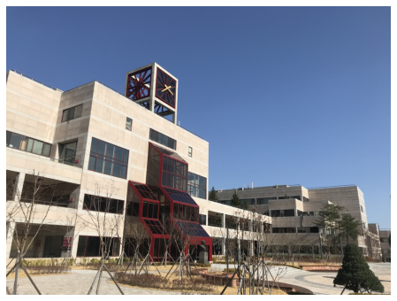

```python
plt.figure(figsize=(10, 6))
plt.imshow(imag1)
plt.axis('off')
plt.show()
```

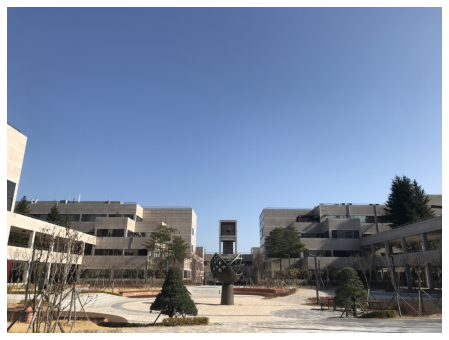

```python
plt.figure(figsize=(10, 6))
plt.imshow(imag2)
plt.axis('off')
plt.show()
```

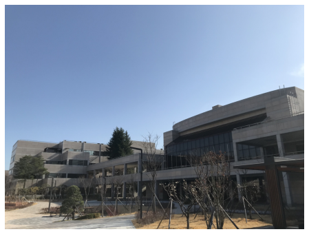

```python
plt.figure(figsize=(10, 6))
plt.imshow(imag3)
plt.axis('off')
plt.show()
```

**Panorama**

Here, we are explaining the basic concept of homography (i.e., perspective transformation).

- Any wide-angle view or representation of a physical space
- images with horizontally elongated fields of view
- idea: projecting images onto a common plane

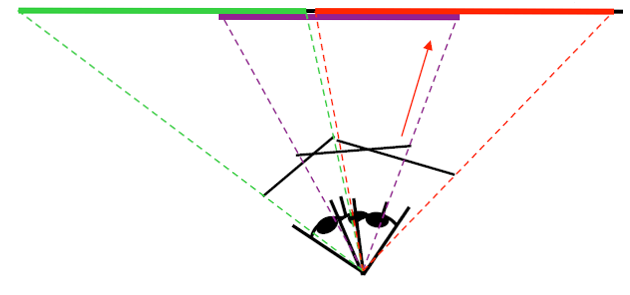

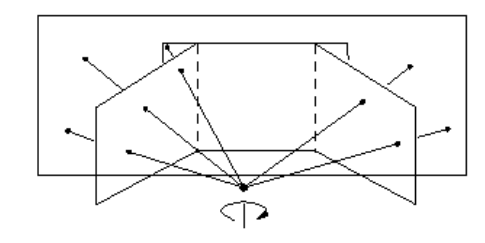

- Camera rotating about its center

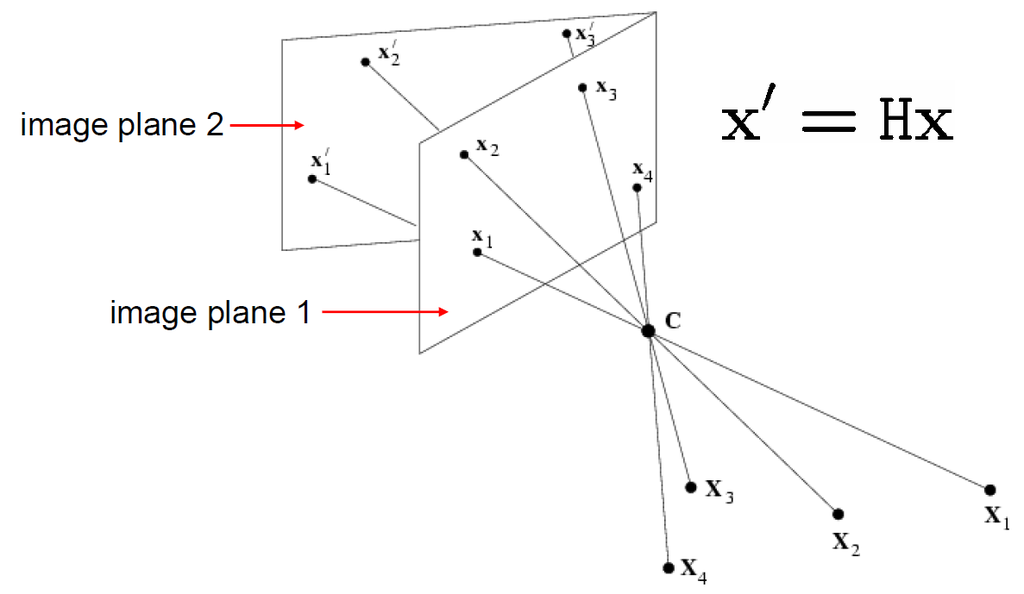

- Two image planes are related by a homography $H$

  Do not worry about a homography transformation. (out of this course's scope)

$$ \begin{bmatrix} x'\\y'\\1 \end{bmatrix} \sim \begin{bmatrix} \omega x'\\\omega y'\\\omega \end{bmatrix} = \begin{bmatrix} a & b & c \\ d & e & f \\ g & h & 1 \end{bmatrix} \begin{bmatrix} x\\y\\1 \end{bmatrix} $$

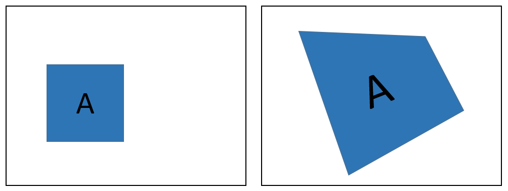

## Find key points between two images

- Suppose these matching points are given.
  - We have manually found the matching points for you, although there is a technique to do this automatically.
- pos1 and pos2 are matching points between img01 and img02
- pos3 and pos4 are matching points between img02 and img03

```python
pos1 = np.array([[2121, 2117, 2749, 3095, 3032, 3375, 3677, 3876],
                 [1431, 2034, 2033, 1885, 2017, 2037, 1885, 2279]], dtype=np.int64)
pos2 = np.array([[188, 58, 828, 1203, 1121, 1437, 1717, 1817],
                 [1217, 1909, 1952, 1827, 1952, 1991, 1870, 2226]], dtype=np.int64)
pos3 = np.array([[2338, 2379, 2658, 2899, 2977, 3272, 2716, 2786],
                 [1948, 1874, 2000, 1837, 1964, 1966, 2143, 2317]], dtype=np.int64)
pos4 = np.array([[109, 178, 497, 795, 851, 1144, 534, 580],
                 [1907, 1828, 1988, 1834, 1971, 1993, 2145, 2333]], dtype=np.int64)
```

(a) Visualization of key points

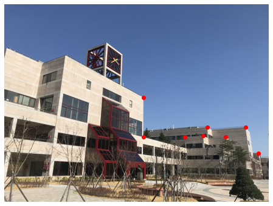

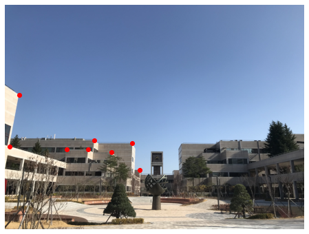

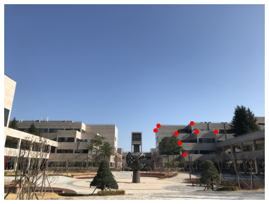

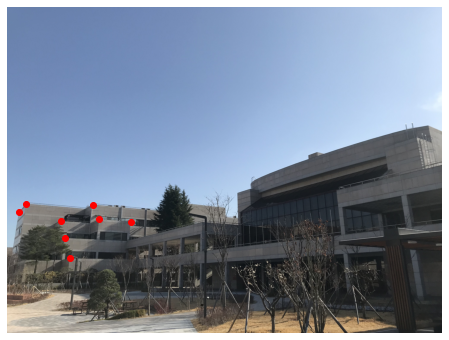

```python
## your code here
## Write down your own code to mark the key points (red dots) on the locations of the given images

# Solution
plt.figure(figsize=(10, 6))
plt.imshow(imag1)
plt.plot(pos1[0,:], pos1[1,:], 'ro', 'linewidth', 1)
plt.axis('off')
plt.show()

plt.figure(figsize=(10, 6))
plt.imshow(imag2)
plt.plot(pos2[0,:], pos2[1,:], 'ro', 'linewidth', 1)
plt.axis('off')
plt.show()

plt.figure(figsize=(10, 6))
plt.imshow(imag2)
plt.plot(pos3[0,:], pos3[1,:], 'ro', 'linewidth', 1)
plt.axis('off')
plt.show()

plt.figure(figsize=(10, 6))
plt.imshow(imag3)
plt.plot(pos4[0,:], pos4[1,:], 'ro', 'linewidth', 1)
plt.axis('off')
plt.show()
```

**Estimation of homography H**

$$ X' = HX $$

where $ X $ and $X'$ are position vectors of key points, and $ H $ is a Perspective Transformation

**Goal: we need to estimate homography $H$ via matching points between two images**

$$\begin{bmatrix} x' \\ y' \\ 1 \end{bmatrix} \sim \begin{bmatrix} \omega x' \\ \omega y' \\ \omega \end{bmatrix} = \begin{bmatrix} \theta_{1} & \theta_{2} & \theta_{3} \\ \theta_{4} & \theta_{5} & \theta_{6} \\ \theta_{7} & \theta_{8} & 1 \end{bmatrix} \begin{bmatrix} x\\ y\\ 1 \end{bmatrix}$$

(b) Show the following equations from the above homography $H$

$$ \begin{align*} x' &= \frac{\theta_1 x+\theta_2 y+\theta_3}{\theta_7 x+\theta_8 y+1} \\ y' &= \frac{\theta_4 x+\theta_5 y+\theta_6}{\theta_7 x+\theta_8 y+1} \end{align*} $$
$$ \begin{align*} \theta_1 x+\theta_2 y+\theta_3 -\theta_7 x'x-\theta_8 x'y-x' &= 0 \\ \theta_4 x+\theta_5 y+\theta_6 -\theta_7 y'x-\theta_8 y'y-y' &= 0 \end{align*} $$

(c) For $m$ pairs of matching potins, show that a feature matrix $\Phi$ can be expressed as follows:

- $ \Phi $ is a feature matrix

$$ \Phi = \begin{bmatrix} x_{1} & y_{1} & 1 & 0 & 0 & 0 & -x'_{1}x_{1} & -x'_{1}y_{1}\\ 0 & 0 & 0 & x_{1} & y_{1} & 1 & -y'_{1}x_{1} & -y'_{1}y_{1}\\ \vdots &\vdots &\vdots &\vdots &\vdots &\vdots &\vdots &\vdots\\ x_{m} & y_{m} & 1 & 0 & 0 & 0 & -x'_{m}x_{m} & -x'_{m}y_{m}\\ 0 & 0 & 0 & x_{m} & y_{m} & 1 & -y'_{m}x_{m} & -y'_{m}y_{m}\end{bmatrix} $$

- $ \theta $ is a column vector for unknown parameters in a perspective transformation $H$

$$ \theta = \begin{bmatrix} \theta_{1} \\ \theta_{2} \\ \theta_{3} \\ \theta_{4} \\ \theta_{5} \\ \theta_{6} \\ \theta_{7} \\ \theta_{8} \end{bmatrix} $$

- $b$ is a column vector for corresponding positions in the base image

$$ b = \begin{bmatrix} x'_{1} \\ y'_{1} \\ x'_{2} \\ y'_{2} \\ \vdots \\ x'_{m} \\ y'_{m} \end{bmatrix} $$

- It ends up becoming a linear regression problem

$$ \min\limits_{\theta} \lVert \Phi\theta - b \rVert _2^2 $$$$ \theta^* = (\Phi^T\Phi)^{-1}\Phi^T b $$

(d) Perspective homography for image 1 and image 2

```python
## your code here
## Construct feature matrix using homography H, and a vector having entries of matching points in image 2

# Solution

Phi01 = []
newpos01 = []
for i in range(8):
    temp1 = [[pos1[0,i], pos1[1,i], 1, 0, 0, 0, -pos2[0,i]*pos1[0,i], -pos2[0,i]*pos1[1,i]],
            [0, 0, 0, pos1[0,i], pos1[1,i], 1, -pos2[1,i]*pos1[0,i], -pos2[1,i]*pos1[1,i]]]
    temp2 = [[pos2[0,i]], [pos2[1,i]]]
    Phi01.append(temp1)
    newpos01.append(temp2)

Phi01 = np.concatenate(Phi01, axis=0)
newpos01 = np.concatenate(newpos01, axis=0).reshape(-1, 1)
Phi01 = np.asmatrix(Phi01)
newpos01 = np.asarray(newpos01)

## your code here
## Define perspective_theta using linear regression

# Solution

perspective_theta = (Phi01.T*Phi01).I*Phi01.T*newpos01
perspective_theta = np.vstack([perspective_theta, [1]])
perspective_theta = perspective_theta.reshape(3, 3)
```

(e) Perspective homography for image 2 and image 3

```python
## your code here
## Construct feature matrix using homography H, and a vector having entries of matching points in image 2

# Solution

Phi03 = []
newpos03 = []
for i in range(8):
    temp1 = [[pos4[0,i], pos4[1,i], 1, 0, 0, 0, -pos3[0,i]*pos4[0,i], -pos3[0,i]*pos4[1,i]],
            [0, 0, 0, pos4[0,i], pos4[1,i], 1, -pos3[1,i]*pos4[0,i], -pos3[1,i]*pos4[1,i]]]
    temp2 = [[pos3[0,i]], [pos3[1,i]]]
    Phi03.append(temp1)
    newpos03.append(temp2)

Phi03 = np.concatenate(Phi03, axis=0)
newpos03 = np.concatenate(newpos03, axis=0).reshape(-1, 1)
Phi03 = np.asmatrix(Phi03)
newpos03 = np.asarray(newpos03)

## your code here
## Define perspective_theta using linear regression

# Solution

perspective_theta3 = (Phi03.T*Phi03).I*Phi03.T*newpos03
perspective_theta3 = np.vstack([perspective_theta3, [1]])
perspective_theta3 = perspective_theta3.reshape(3, 3)
```

# Problem 4

We saw many optimization problems in a machine learning context and witnessed that $L_1$ norm reguarlization provides not only small, but also sparse decision variables. In this problem we will use a linear programming to solve $L_1$ norm optimization problems instead of simply using cvx.

(a) Show that

$$ \lvert y_i \rvert = \max \left(-y_i,y_i \right) $$

(b) Show that, by introducing slack variable $t_i$, the absolute value optimization problem can be coverted to

$$\min \,\lvert y_i \rvert = \min \left\{\max \left(-y_i,y_i \right) \right\} \quad \iff \quad \begin{align*} \min \quad & t_i \\ \text{subject to} \quad & y_i \leq t_i \\ - & y_i \leq t_i \end{align*} $$

(c) Suppose $A\theta-b = r$ and $t = \begin{bmatrix} t_1 & t_2 & \cdots & t_m \end{bmatrix}^T $, then show that $L_1$ norm fitting/approximation problem, i.e., sum of (absolute) residuals can be coverted to

$$\min \,\lVert A\theta-b \rVert_{1} \quad \iff \quad \begin{align*} \min \quad & t_1 + \cdots + t_m \\ \text{subject to} \quad & A\theta - b \leq t \\ - & (A\theta - b) \leq t \end{align*} $$

(d) Change the above optimization problem to a linear programming (LP) in matrix form where $\mathbb{1} = \begin{bmatrix} 1& \cdots & 1\end{bmatrix}^T$ and $\mathbb{0} = \begin{bmatrix} 0& \cdots & 0\end{bmatrix}^T$

$$ \begin{align*} \min \quad & \begin{bmatrix} \mathbb{0}^T & \mathbb{1}^T \end{bmatrix} \begin{bmatrix} \theta \\ t \end{bmatrix} \\ \text{subject to} \quad & \begin{bmatrix} A & -I \\ -A & -I \end{bmatrix}\begin{bmatrix} \theta \\ t \end{bmatrix} \leq \begin{bmatrix} b \\ -b \end{bmatrix} \end{align*} $$

(e) Use `cvxpy` in Python to find and plot a linear regression for data points with the above formulation

```python
import numpy as np
x = np.array([0.1, 0.4, 0.7, 1.2, 1.3, 1.7, 2.2, 2.8, 3.0, 4.0, 4.3, 4.4, 4.9])
y = np.array([0.5, 0.9, 1.1, 1.5, 1.5, 2.0, 2.2, 2.8, 2.7, 3.0, 3.5, 3.7, 3.9])
```

```python
## your code here
```

# Solution 4

(a)

$\text{(i) }\text{if } y_i < 0\;(-y_i > 0)$

$$ LHS=\lvert y_i\rvert =-y_i\\ RHS=\max(-y_i, y_i)\to RHS=-y_i\\ $$

$\text{(ii) }\text{if }y_i\geq0\;(-y_i\leq0)$

$$ LHS=\lvert y_i\rvert =y_i \\ RHS=\max(-y_i, y_i) \to RHS=y_i\\ $$$$\text{so, }LHS=RHS\implies \lvert y_i\rvert=\max(-y_i, y_i)$$

(b)

Let define set $T$ and $G$ as following

$$ T=\{t_i | t_i \geq \max(-y_i,y_i)\;\forall_i\}\\ G=\{g_i | g_i = \max(-y_i,y_i)\;\forall_i\} $$

If there is $j$ s.t

$$ \max(-y_j,y_j)\leq \max(-y_i,y_i)\;\forall_i,\\ \text{That means, }\max(-y_j,y_j)=\min[\max(-y_i,y_i)] $$

By definition of $t_i$,

$$ \begin{align} \max(-y_j,y_j) & \leq \max(-y_i,y_i)\leq t_i \\ \max(-y_j,y_j) & \leq t_i \to \min\;t_i=\max(-y_j,y_j)=\min[\max(-y_i,y_i)] \end{align} $$

(c)

$$ \lVert t\rVert_1=t_1+t_2+t_3+\cdots+t_m $$

from previous problem

$$ \\t\geq \max(-r,r)\to \min\;t=\min[\max(-r,r)] $$$$ \min\lVert t\rVert_1=\min\lVert\max(-r,r)\rVert_1 $$$$ \lVert\max(-r,r)\rVert_1=\lVert -r\rVert_1=\lVert r\rVert_1=\lVert A\theta -b\rVert_1 $$$$ \text{so, }\min\lVert t\rVert_1=\min\lVert A\theta -b\rVert_1\\\\ $$

Note

$$ \quad\text{if }t\geq \max(-r,r)\implies \lVert t\rVert_1\geq\lVert\max(-r,r)\rVert\\ \quad\text{since }t\geq \max(-r,r)\geq0\;,\text{ this inequality is vaild} $$

(d)

$$ \lVert t\rVert_1=t_1+t_2+t_3+\cdots+t_m= \begin{bmatrix}0&\cdots&0&1&\cdots&1\end{bmatrix} \begin{bmatrix}\theta_1\\\vdots\\\theta_n\\t_1\\\vdots\\t_m\end{bmatrix} $$

$$ \begin{cases} A\theta-b\leq t\\ -(A\theta-b)\leq t \end{cases} \implies \begin{cases} A\theta-t\leq b\\ - A\theta-t\leq -b \end{cases} \implies \begin{bmatrix} A & -I \\ -A & -I \end{bmatrix} \begin{bmatrix} \theta \\ t \end{bmatrix} \leq \begin{bmatrix} b \\ -b \end{bmatrix} $$

```python
import numpy as np
x = np.array([0.1, 0.4, 0.7, 1.2, 1.3, 1.7, 2.2, 2.8, 3.0, 4.0, 4.3, 4.4, 4.9])
y = np.array([0.5, 0.9, 1.1, 1.5, 1.5, 2.0, 2.2, 2.8, 2.7, 3.0, 3.5, 3.7, 3.9])
```

```python
x = np.array([0.1, 0.4, 0.7, 1.2, 1.3, 1.7, 2.2, 2.8, 3.0, 4.0, 4.3, 4.4, 4.9]).reshape(-1,1)
y = np.array([0.5, 0.9, 1.1, 1.5, 1.5, 2.0, 2.2, 2.8, 2.7, 3.0, 3.5, 3.7, 3.9]).reshape(-1,1)

m = y.shape[0]
A = np.hstack([x, x**0])
A = np.asmatrix(A)
b = y
ones = np.ones([m, 1])
zeros = np.zeros([m, 1])
```

```python
import cvxpy as cvx

theta = cvx.Variable([2, 1])
t = cvx.Variable([m, 1])
objective = cvx.Minimize(cvx.sum_squares(t))
constraints = [(A*theta - t) <= y, -(A*theta - t) <= -b]
prob = cvx.Problem(objective, constraints).solve()

theta.value
```

```
array([[0.67129504],
       [0.65306552]])
```

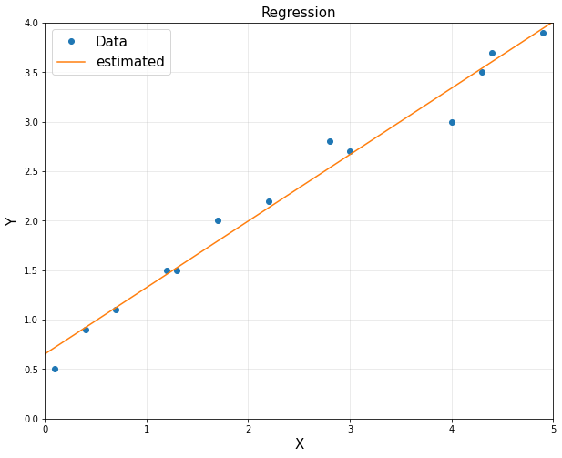

```python
xp = np.arange(0, 5, 0.01).reshape(-1, 1)
yp = theta.value[0,0]*xp + theta.value[1,0]

plt.figure(figsize=(10, 8))
plt.title('Regression', fontsize=15)
plt.plot(x, y, 'o', label='Data')
plt.plot(xp, yp, label='estimated')
plt.xlabel('X', fontsize=15)
plt.ylabel('Y', fontsize=15)
plt.axis([0, 5, 0, 4])
plt.legend(fontsize=15)
plt.grid(alpha=0.3)
plt.show()
```

# Problem 9

Load [lasso_input_data.pkl](https://www.dropbox.com/s/ohpr04x7s45o60i/lasso_input_data.pkl?dl=1) and [lasso_target_data.pkl](https://www.dropbox.com/s/f0nwcnxcztjzy2e/lasso_target_data.pkl?dl=1) using the following command.

```python
import numpy as np
import matplotlib.pyplot as plt
from six.moves import cPickle

A = cPickle.load(open('./data_files/lasso_input_data.pkl', 'rb'))
y = cPickle.load(open('./data_files/lasso_target_data.pkl', 'rb'))
# Pickle is not important.
```

In this problem, you are asked to predict a target value $\hat y$ from 13 features (input data). Assume that your model has the following relationship ($\omega_0 = 0$):

$$\omega_1 x_1 + \omega_2 x_2 + \cdots + \omega_{13} x_{13} = \hat y$$

(a) [3pt] Build the linear regression model using the Lasso regularizer.

(Hint : You can use cvxpy module to solve the above optimization problem)

```python
# Write your code here
```

(b) [3pt] After applying Lasso, we can select meaningful features. Plot the magnitudes of all $\omega$'s and tell which features are important.

```python
# Write your code here
```

(c) [3pt] Update the linear regresion model with the selected features only.

```python
# Write your code here
```

# Solution 9

Load [lasso_input_data.pkl](https://www.dropbox.com/s/ohpr04x7s45o60i/lasso_input_data.pkl?dl=1) and [lasso_target_data.pkl](https://www.dropbox.com/s/f0nwcnxcztjzy2e/lasso_target_data.pkl?dl=1) using the following command.

```python
import numpy as np
import matplotlib.pyplot as plt
from six.moves import cPickle

A = cPickle.load(open('./data_files/lasso_input_data.pkl', 'rb'))
y = cPickle.load(open('./data_files/lasso_target_data.pkl', 'rb'))
```

In this problem, you are asked to predict a target value $\hat y$ from 13 features (input data). Assume that your model has the following relationship ($\omega_0 = 0$):

$$\omega_1 x_1 + \omega_2 x_2 + \cdots + \omega_{13} x_{13} = \hat y$$

(a) [3pt] Build the linear regression model using the Lasso regularizer.

(Hint : You can use cvxpy module to solve the above optimization problem)

```python
# Write your code here
import cvxpy as cvx

y = y.reshape(506,1)
d = 13

lamb = 20
theta = cvx.Variable([d, 1])
obj = cvx.Minimize(cvx.sum_squares(A*theta - y) + lamb*cvx.norm(theta, 1))
prob = cvx.Problem(obj, [])
result = prob.solve()
print(theta.value)
```

```
[[-9.04219506e-02]
 [ 4.91200936e-02]
 [-1.49506846e-02]
 [ 2.50044065e+00]
 [ 1.12400830e-20]
 [ 5.76784573e+00]
 [-9.14331903e-03]
 [-9.34004299e-01]
 [ 1.72291748e-01]
 [-1.00519860e-02]
 [-3.89478763e-01]
 [ 1.48170211e-02]
 [-4.33160161e-01]]
```

(b) [3pt] After applying Lasso, we can select meaningful features. Plot the magnitudes of all $\omega$'s and tell which features are important.

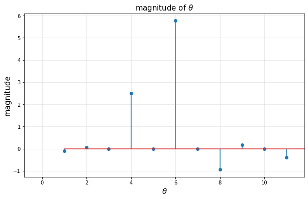

```python
# Write your code here
#
# Regulization (= lasso nonlinear regression) encourages zero weights
plt.figure(figsize = (10, 6))
plt.title(r'magnitude of $\theta$', fontsize = 15)
plt.xlabel(r'$\theta$', fontsize = 15)
plt.ylabel('magnitude', fontsize = 15)
plt.stem(np.linspace(1, 13, 13).reshape(-1, 1), theta.value)
plt.axis('equal')
plt.xlim([0.5, 10.5])
plt.grid(alpha = 0.3)
plt.show()
```

(c) [3pt] Update the linear regresion model with the selected features only.

```python
# Write your code here
#
features = [4, 6, 8, 11]

theta_0 = np.vstack(theta[i-1].value for i in features)
A_0 = np.column_stack(A[:,j-1] for j in features)

lamb = 20
theta = cvx.Variable([len(features), 1])
obj = cvx.Minimize(cvx.sum_squares(A_0*theta - y) + lamb*cvx.norm(theta_0, 1))
prob = cvx.Problem(obj, [])
result = prob.solve()
print(theta.value)
```

```
[[ 3.45366475]
 [ 7.13766324]
 [ 0.32004063]
 [-1.28737363]]
```